# Paper Replication Report

At the beginning of the simulation, the **DAMP** diffusion field is also initiated. The name DAMP here comes from the paper we used as a reference, but this can also be thought of as a viral load introduced to the cell environment. We can observe a representation of a drop of the virus at a certain point in space, in this case not random at position (85, 50, 0), or center-right, and a value of 30 (arbitrary unit).

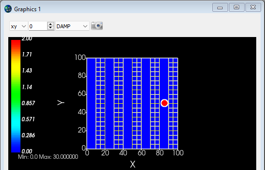

The presence of DAMP will give origin to cells called Pyro_DAMP(green), which represents cells that initiated pyroptosis induced by the viral load.

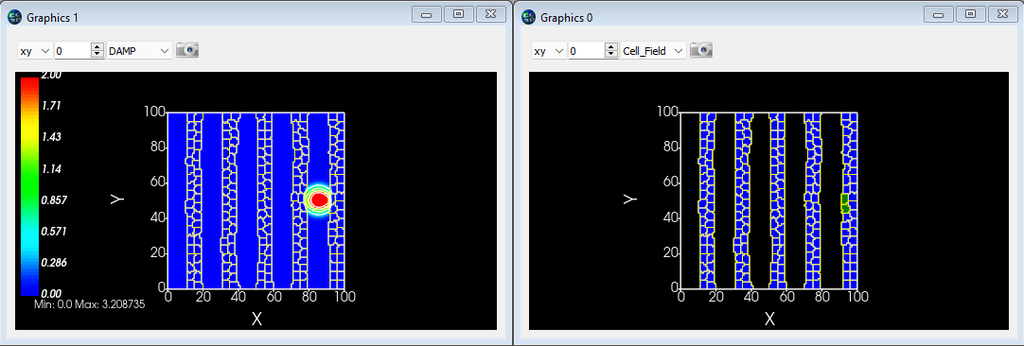

Another essential point to note about DAMP is after its initiation at MCS 0, the only addition of DAMP to the system is done by cells infected reproducing copies of the virus. The first pyroptotic cell created will always be a Pyro_DAMPS type; since the only diffusion field present in the simulation is the DAMP, the initiation of the IL1B diffusion field will only happen after a cell start the pyroptosis pathway.

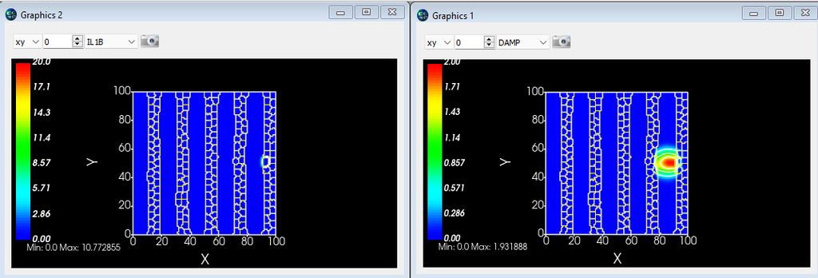

Here we can see the cell that initiated pyroptosis also started to release IL1B into the environment; if we check the Antimony plot once more, we will know when it happens after the cell gets infected.

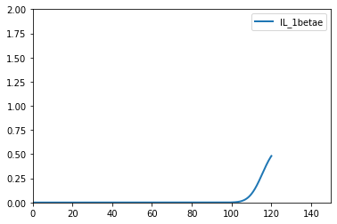

```python
s = r.simulate(0, 120, 1000, ['time','IL_1betae'])
r.plot(ylim=[0.0, 2.0],xlim=[0,150])
r.show()
r.resetAll()
```

With this plot we cans see that after the cell start pyroptosis a little bit after the 100 mcs.

The production of virus(DAMP) happens in two ways; first, there is a continuous production of virus set to be a constant value at the beginning of the simulation, assuming that the virus tells the cell to create copies at the time of infection. The second way is the release of the virus after cell death since pyroptotic cells die by rupture of the membrane. The assumption here is that there would be viral release if any virus was produced by the cell but did not make its way outside the cell by normal means.

The initiation of the cell type Pyro_IL1beta(red) is only done by the presence of the IL1B field:

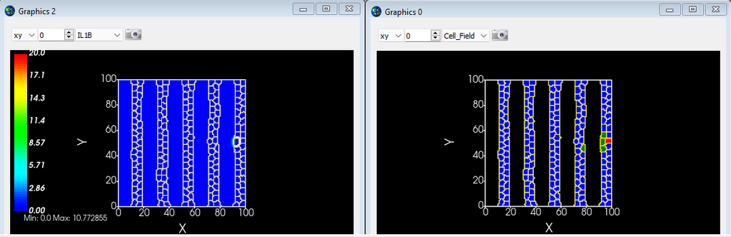

The interaction of both fields create a "dispute" on which type of cell the healthy cell will become after a couple of cells initiate pyroptosis

After the volume of a cell goes over 50% of its original volume, the cell becomes Dead_Pyro(pink)

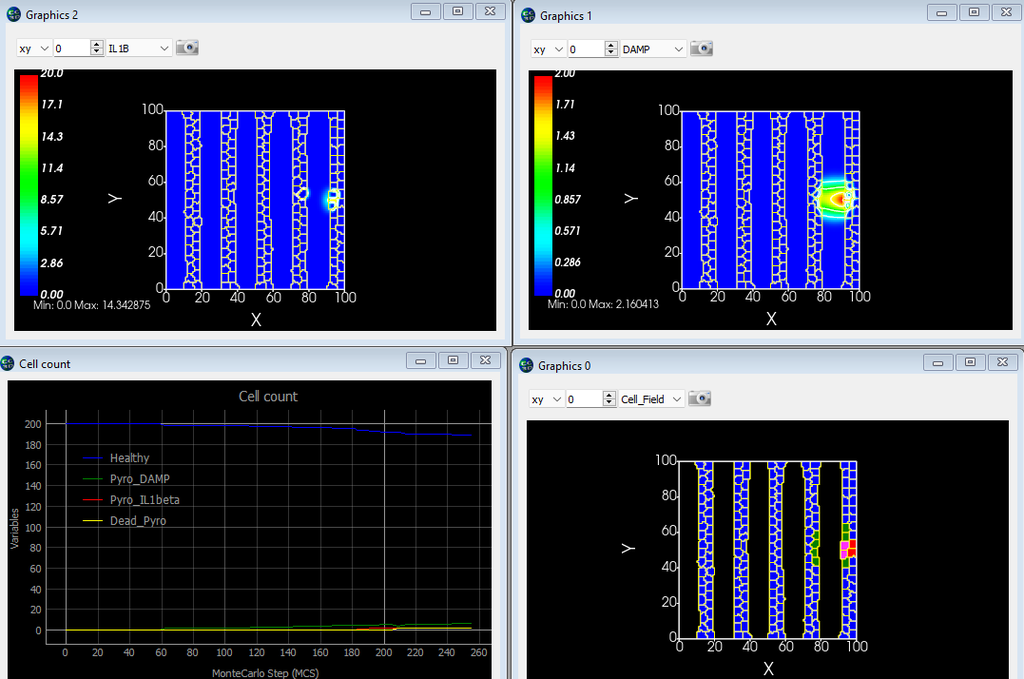

The model simulates how the virus spreads, given that cells would initiate pyroptosis by limiting the number of cells that can be infected and producing more viruses.

Here we give the user a way to control how many viruses the cell produces after each MCS and the option to control how many viruses are released in the burst of cell death.

Another steering panel available for the user is the decay of IL1B in the medium; this will allow us to see how different the scenario would be if only the neighboring cells could start pyroptosis for example

This is an example after the default values ran close the end of the simulation when all the cells die.

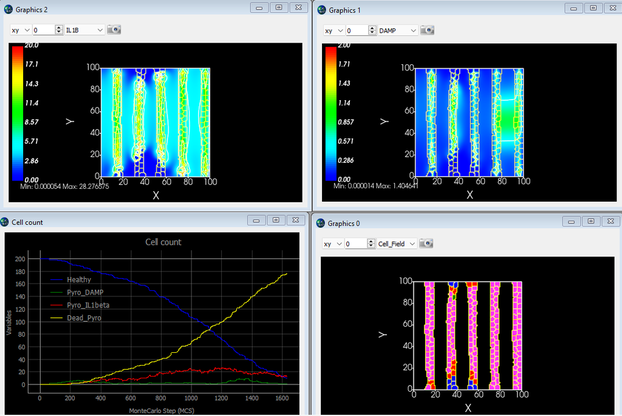

Some other examples:

The case where the number of cells starting pyroptosis is closely the same.

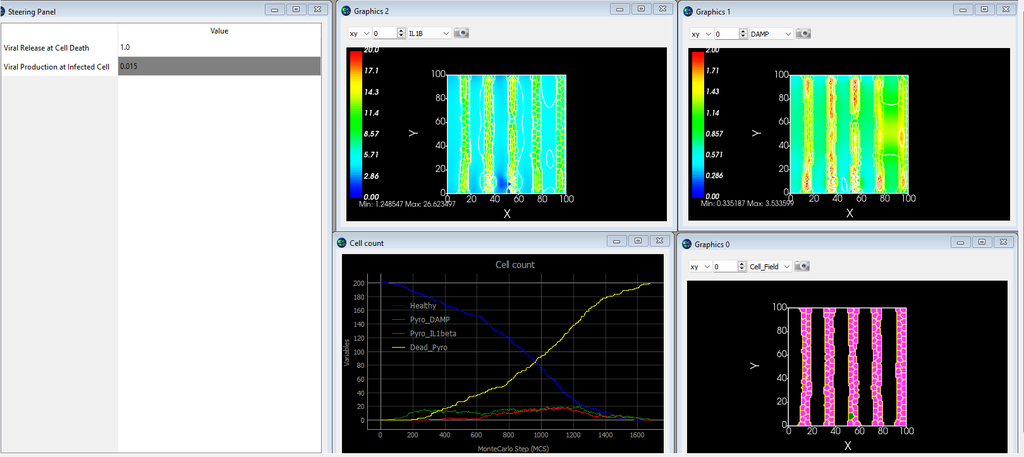

The case that viral initiated pyroptosis is dominant be cause of viral production.

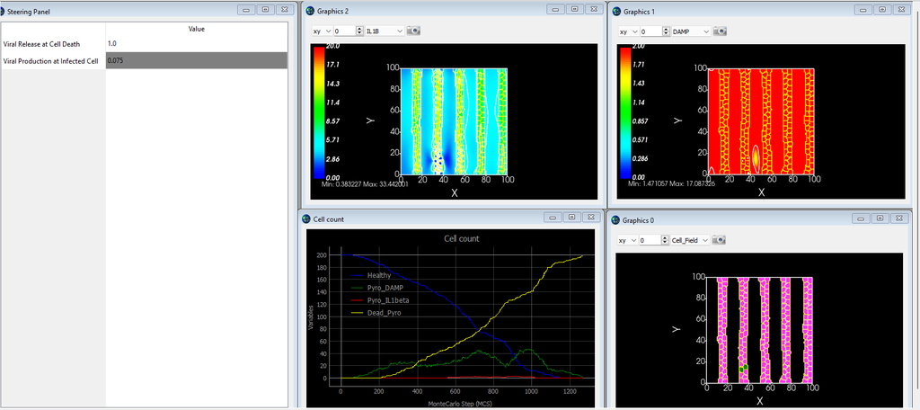

The case where the number of virus release after cell death is higher.

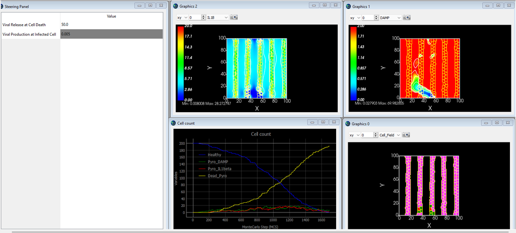

The case where the decay fo ILB1 to the medium is higher, the default is 0 meaning no decay in the medium.

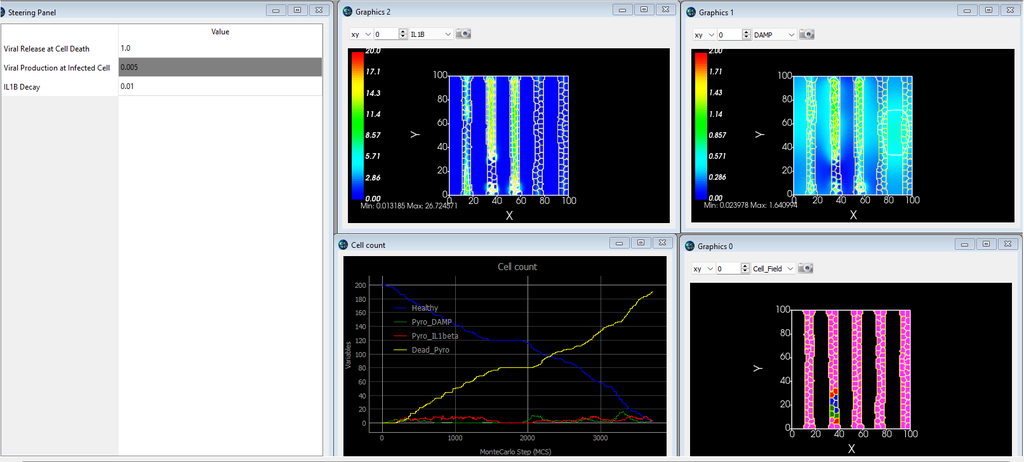